```python
%matplotlib inline
```

# Data processing - short problems

# Time Series

These short problems are focused on time series processing and organized in the following sub-categories :

- Algorithm building
- Error correction
- Module utilization
- Code completion

Each one will be comprised of parts :

- For the **candidate**
  1. Context and goal
  2. Asked solution and method of evaluation
  3. Needed ressources
  4. Problem itself
- For **us**
  1. Proposed solution
  2. Algorithm to test candidate's output

## Algorithm building

These exercises aim to evaluate the candidate's ability to abstract a real-life problem and build a working solution with the tools he knows.

### "Trend (seasonality) extraction" [MEDIUM]

Required time estimation : 15-20 minutes.

**Candidate** : Context and goal

> Common finance applications imply the use of time series data. However, the widely known theory around ARMA models is based on the assumption that the described process is stationnary. Hence, the mandatory trend and seasonality extraction task lies with the analyst.

**Candidate** : Asked solution and method of evaluation

**Candidate** : Needed ressources

> You will not need any specific ressources for this exercise.

*Comment : should the candidate already fully understand the detrending (deseasonalizing) methods ? should we give a reminder ?*

**Candidate** : Problem

> The data has been extracted with the following code :

```python
import datetime
import pandas_datareader.data as web
import pandas as pd

start = datetime.datetime(2012, 7, 3)
end = datetime.datetime(2012, 9, 28)

google = web.DataReader("GOOG", 'yahoo', start, end)["Open"]

# Since market values are only avaible on workdays,
# we will interpolate the values on the other days.

new_index = pd.DatetimeIndex(start="2012-07-03",
                             end="2012-09-28",
                             freq="D")

google = google.reindex(new_index)
google.interpolate(method="nearest", inplace=True)
```

> Here is what it looks like :

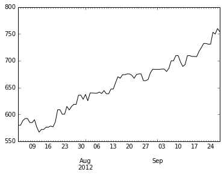

```python
google.plot(style="k")
```

> Now, your turn to code. Remember, you need to return the untrended `Series`.

*[HINT] : one might build a complete solution using only `numpy` and `Pandas`*

```python
def untrend(s): # Consider s a Series object

    # Insert your code here

    return s_notrend # Return untrended Series
```

**Evaluation** : Proposed solution

> We built a solution using simple OLS regression on the given data, which requires some little preprocessing. We could have used a built-in function, such as [`statsmodels.tsa.tsatools.detrend`](http://statsmodels.sourceforge.net/stable/generated/statsmodels.tsa.tsatools.detrend.html#statsmodels.tsa.tsatools.detrend)

```python
import numpy as np

def untrend_sol(s):

    s_modif = s.reset_index()

    # Extract coordinates
    x = s_modif.index.values
    y = s_modif["Open"]

    # Extract slope(a) and intercept(b) from linear regression
    # We use np.linalg.lstsq, following the example
    # M is [[x 1]] in the matrix repr of linear reg

    M = np.vstack([x, np.ones(len(x))]).T

    a, b = np.linalg.lstsq(M, y)[0]

    print("Slope : {0}\nIntercept : {1}".format(a,b))

    trend = a*x + b
    s_trend = pd.Series(trend, s.index)

    s_notrend = s - s_trend

    return s_notrend
```

We can apply this function to our `Series` object and plot the result :

```
Slope : 1.96369182521
Intercept : 569.359849694
```

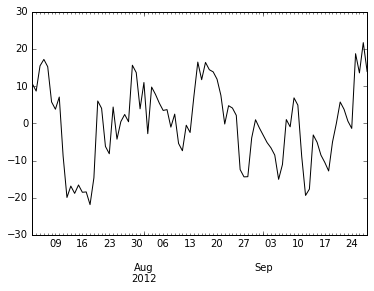

```python
google_nt = untrend_sol(google)
google_nt.plot(style="k")
```

The result has apparently a 0 mean over the whole period, and doesn't show evidence of remaining linear trend.

**Evaluation** : Output evaluation

> We simply try to extract a linear trend from the output. If the intercept or the slope coefficients are too far from 0, we consider the assignment failed.

```python
def untrend_check(s):

    s_modif = s.reset_index()

    # Extract coordinates
    x = s_modif.index.values
    y = s_modif[0]

    # Extract slope(a) and intercept(b) from linear regression
    # We use np.linalg.lstsq, following the example
    # M is [[x 1]] in the matrix repr of linear reg

    M = np.vstack([x, np.ones(len(x))]).T

    a, b = np.linalg.lstsq(M, y)[0]

    print("Slope : {0}\nIntercept : {1}".format(a,b))

    return not( abs(a) > 1e-8 or abs(b) > 1e-8 )
```

```python
untrend_check(google_nt)
```

```
Slope : 1.59885122483e-15
Intercept : 2.45962667982e-13
```

```
True
```

**More**

We could develop this exercise with some ideas :

- Detection of structural change
- Higher order trends
- Multiple spans for seasonality

We should maybe add "levels of failure" to the notation, instead of a simple binary notation.

### "Velocity and acceleration in a curve" [EASY]

Required time estimation : 5 minutes.

**Candidate** : Context and goal

> Numerous financial models make use of physical principles. For example, we hear about "mean-reversion", "momentum" and more. In specific applications (such as [Kinetic Component Analysis](http://papers.ssrn.com/sol3/papers.cfm?abstract_id=2422183)), we might consider that a given time series is a curve, and analyze with kinetic concepts : velocity and acceleration.

**Candidate** : Asked solution and method of evaluation

> In this exercise, we will ask you to compute pointwise velocity and acceleration, assuming each point represents position. You should use simple numerical approximations, such as $v(t) = {p(t+h) - p(t) \over h} .$ We evaluate your output by comparing it to ours (we use the left-side approximation, i.e. $\dot{x}(t) = x(t) - x(t-1) $ ).

**Candidate** : Needed ressources

> None required (maybe [`Pandas.Series` documentation](http://pandas.pydata.org/pandas-docs/stable/generated/pandas.Series.html)).

**Candidate** : Problem

> You will apply these methods to real-world data, i.e. the daily closing share value for Google, from 2010 to 2013. These data are stored in a `Pandas.Series` object, and were extracted with the following :

```python
import datetime
import pandas_datareader.data as web
import pandas as pd

start = datetime.datetime(2010, 1, 4)
end = datetime.datetime(2013, 12, 31)

google = web.DataReader("GOOG", 'yahoo', start, end)["Close"]

# Since market values are only avaible on workdays,
# we will interpolate the values on the other days.

new_index = pd.DatetimeIndex(start="2010-01-04",
                             end="2013-12-31",
                             freq="D")

google = google.reindex(new_index)
google.interpolate(method="linear", inplace=True)
```

> Here is what it looks like :

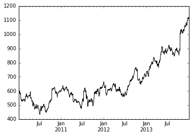

```python
google.plot(style='k')
```

> Please define two functions, taking the `Series` object as parameter and computing velocity and acceleration respectively, using the following code structure :

```python
# s_pos, s_vel, and s_acc are respectively the position,
# velocity and acceleration (as Pandas.Series).

# Velocity computation
def get_velocity(s_pos):

    # Enter your code here

    return s_vel

# Acceleration computation
def get_acceleration(s_pos):

    # Enter your code here

    return s_acc
```

**Evaluation** : Proposed solution

> As said above, we use left-side approximation, or first differences (see [`Series.diff()`](http://pandas.pydata.org/pandas-docs/stable/generated/pandas.Series.diff.html) method). We notice that acceleration is the velocity in the velocity curve, hence the simplified **`get_acceleration`** code.

```python
# s_pos, s_vel, and s_acc are respectively the position,
# velocity and acceleration (as Pandas.Series).

# Velocity computation
def get_velocity_sol(s_pos):

    s_vel = s_pos.diff()

    return s_vel

# Acceleration computation
def get_acceleration_sol(s_pos):

    s_acc = get_velocity(
        get_velocity(s_pos)
    )

    return s_acc
```

**Evaluation** : Output evaluation

> We compute our solutions and compare them to the candidate's.

```python
def vel_acc_check(s_pos, s_vel, s_acc):
    s_vel_sol = get_velocity_sol(s_pos)
    s_acc_sol = get_acceleration_sol(s_pos)

    mse_vel = ((s_vel-s_vel_sol)**2).mean()
    mse_acc = ((s_acc-s_acc_sol)**2).mean()

    return mse_vel + mse_acc
```

*Just to test our evaluation function, let's define another approach and test it :*

```python
def r_vel(s):
    shifted = s.shift(1)

    return shifted-s

right_eval = vel_acc_check(google,
                           r_vel(google),
                           r_vel(r_vel(google)))
left_eval = vel_acc_check(google,
                          get_velocity_sol(google),
                          get_acceleration_sol(google))

print("Right-side computation MSE : {0}\nLeft-side computation MSE : {1}"\
     .format(right_eval, left_eval))
```

```
Right-side computation MSE : 261.242720394
Left-side computation MSE : 0.0
```

*This seems a bit too discriminative... The two methods are correct but produce strongly different results.*

**More** :

We may want to improve this exercise with these ideas :

- Using a more subtle curve, such as a yield curve, to plot interesting, less-noisy, velocity/acceleration curves.
- Applying these velocity/acceleration to a specific use (KCA ?)
- ...

## Error correction

These problems target the candidate's ability to understand existing code and spot the mistakes that prevent it from either working or computing correct results.

### "Variance computation" [EASY]

Required time estimation : 5 minutes

**Candidate** : Context and goal

> Computing simple statistical parameters for random processes, such as empirical variance, is often used for financial models calibration. There are plenty of existing functions to perform this kind of computation; nevertheless, a Data Scientist will sometimes need to perform these computations manually in order to adjust the formula's parameters.

**Candidate** : Asked solution and method of evaluation

> We implemented a simple code to compute rolling-window variances, but some errors prevent it from working. Find and correct these errors, and we will test whether the output is correct or not (binary evaluation).

**Candidate** : Needed ressources

> Understanding how empirical variance is computed is mandatory, but should already be in your skillset. Hence, you won't need any additional ressources.

**Candidate** : Problem

> Here is our code. It takes a given time series (`Pandas.Series` object) as parameter, along with the window-size to compute the variance; it then returns a `Series` containing the computed variances. As you will often encounter poorly commented code, we did not comment this code on purpose to make the understanding a bit more tedious...

[figure not shown]

```python
import numpy as np
import pandas as pd

def window_var(s, window_size):
    dt_index = s.index
    s_values = s.values

    variances = np.zeros(len(s_values))
    for k in range(len(s_values)):
        vals = s_values[k:k+window_size]

        variances[k] = np.sum(vals**2)/window_size

    return pd.Series(variances, dt_index)
```

**Evaluation** : Proposed solution

> We made two mistakes in the code above : the **for loop goes too far** (got to take window-size into account), and the empirical variance **formula is wrong** (we shouldn't compute the sum of squared values but the sum of squared mean deviations).

```python
import numpy as np
import pandas as pd

def window_var(s, window_size):
    dt_index = s.index
    s_values = s.values

    variances = np.zeros(len(s_values))
    for k in range(len(s_values)-window_size): # corrected range in the for loop
        vals = s_values[k:k+window_size]

        vals_mean = vals.mean() # windowed mean

        # corrected formula
        variances[k] = np.sum((vals - vals_mean)**2)/window_size

    return pd.Series(variances, dt_index)
```

*Just to confirm our code isn't too far from Pandas builtin methods* :

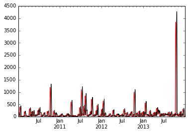

```python
test1 = window_var(google, 10)
test2 = google.rolling(window=10).var()

test1.plot(style="r")
test2.plot(style="k")
```

**Evaluation** : Output evaluation

### "Portfolio selection"

**Candidate** : Context and goal

**Candidate** : Asked solution and method of evaluation

**Candidate** : Needed ressources

**Candidate** : Problem

**Evaluation** : Proposed solution

**Evaluation** : Output evaluation

## Module utilization

These problems will help us assess the candidate's comprehension of popular Python modules and ability to make use of these modules built-in functions to answer simple use-cases.

### "Pandas - window functions"

**Candidate** : Context and goal

**Candidate** : Asked solution and method of evaluation

**Candidate** : Needed ressources

**Candidate** : Problem

**Evaluation** : Proposed solution

**Evaluation** : Output evaluation

### "Statsmodels - filters"

**Candidate** : Context and goal

**Candidate** : Asked solution and method of evaluation

**Candidate** : Needed ressources

**Candidate** : Problem

**Evaluation** : Proposed solution

**Evaluation** : Output evaluation

## Code completion

These exercises will focus on understanding quickly a more or less complicated situation, with a partially implemented solution the candidate will have to complete in order to obtain a controllable result.

### "Kinetic Component Analysis - Fast Fourier Transform" [HARD]

**Candidate** : Context and goal

**Candidate** : Asked solution and method of evaluation

**Candidate** : Needed ressources

**Candidate** : Problem

**Evaluation** : Proposed solution

**Evaluation** : Output evaluation